# Session 1 — Is It Really a Straight Line?

Checking linearity · polynomials · categorising · transformations · U-shapes hidden by a linear term · Lab 1

Community Medicine Workshop

## Where we are

- Regression workshop: every continuous predictor entered as a **straight line**
- Today: **how to see** that the line is wrong, and the **simple** fixes
- By the end you can:
  - use **residual plots and smoothers** to detect curvature
  - fit **polynomial** and **log** terms
  - explain what **categorising** costs
  - see how a **linear term can hide a U-shape**

## Our data: an NCD risk-factor survey

- **4,000 adults** aged 18 to 80 (synthetic)
- **SBP** (mmHg) and **10-year CVD event** (`cvd10`, 10% had one)
- Age, BMI, salt (g/day), activity (hours/week), sex, smoking
- Questions: does SBP rise **evenly** with age? Does CVD risk rise **steadily** with BMI?

```r
ncd |> select(age, sex, bmi, salt, activity, smoker, sbp, cvd10) |> head(6)
```

```
# A tibble: 6 × 8
    age sex     bmi  salt activity smoker   sbp cvd10
  <dbl> <fct> <dbl> <dbl>    <dbl>  <dbl> <dbl> <dbl>
1    66 Male   25.4  12.4      3.5      0   130     0
2    23 Male   25.3   8.5      4.7      0   127     0
3    49 Male   27    10.2      3.6      1   126     0
4    43 Male   18.6   6.4      3.6      1    99     0
5    34 Male   23.3   9.7      5.4      1   116     0
6    36 Male   23.9   8.2      2        0    94     0
```

# Topic 1 — Seeing curvature

## Straight line vs smoother

```r
ggplot(ncd, aes(age, sbp)) + geom_point(alpha = 0.12) + geom_smooth(method = "lm", colour = col_red, se = FALSE) + geom_smooth(method = "loess", colour = col_blue, se = FALSE, formula = y ~ x) + labs(x = "Age (years)", y = "SBP (mmHg)")
```

The **red** line says “the same rise per year at every age”. The **blue** loess smoother shows SBP rising **slowly until about 45 and faster after**.

## Straight line vs smoother

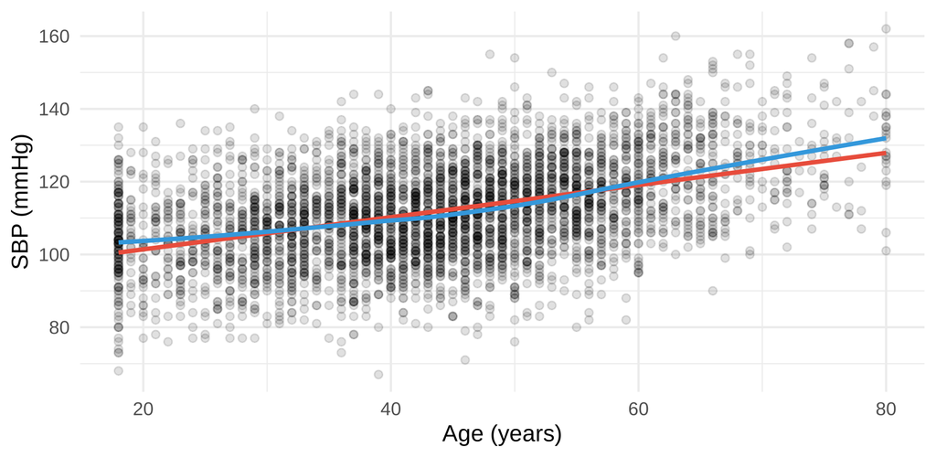

## Residuals against the predictor

```r
m_lin <- lm(sbp ~ age + bmi + salt + activity + sex + smoker, data = ncd)
ggplot(data.frame(age = ncd$age, res = resid(m_lin)), aes(age, res)) + geom_point(alpha = 0.12) + geom_smooth(se = FALSE, formula = y ~ x, method = "loess") + geom_hline(yintercept = 0, linetype = 2) + labs(y = "Residual")
```

## Residuals against the predictor

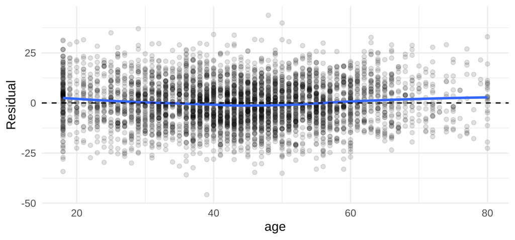

# Topic 2 — Simple fixes

## Polynomial terms

```r
m_quad <- lm(sbp ~ poly(age, 2) + bmi + salt + activity + sex + smoker, data = ncd)
anova(m_lin, m_quad)
```

```
Analysis of Variance Table

Model 1: sbp ~ age + bmi + salt + activity + sex + smoker
Model 2: sbp ~ poly(age, 2) + bmi + salt + activity + sex + smoker
  Res.Df    RSS Df Sum of Sq      F    Pr(>F)
1   3993 511350
2   3992 506767  1      4583 36.102 2.039e-09 ***
---
Signif. codes:  0 '***' 0.001 '**' 0.01 '*' 0.05 '.' 0.1 ' ' 1
```

```r
c(linear = AIC(m_lin), quadratic = AIC(m_quad)) |> round(0)
```

```
   linear quadratic
    30771     30737
```

- Adding **age²** improves the fit (F test p ≈ 2×10⁻⁹; AIC down by about **34**)
- `poly(age, 2)`: **orthogonal** terms; `age + I(age^2)`: raw terms
- Polynomial coefficients are **hard to read**: look at the **curve**; they misbehave at the **ends**

## Categorising the predictor

```r
ncd <- ncd |> mutate(age_grp = cut(age, c(0, 29, 44, 59, 100), labels = c("<30", "30-44", "45-59", "60+")))
m_cat <- lm(sbp ~ age_grp + bmi + salt + activity + sex + smoker, data = ncd)
c(linear = AIC(m_lin), quadratic = AIC(m_quad), four_groups = AIC(m_cat)) |> round(0)
```

```
     linear   quadratic four_groups
      30771       30737       30810
```

The four age groups fit **worse than a straight line** (AIC 30,810). Categorising **throws away** the variation within a group, forces **steps** at arbitrary cut-points, loses **power**, and hides the shape. Use groups to **describe** (a table), not to **model**.

## Transformations

```r
m_log <- lm(sbp ~ age + bmi + salt + log1p(activity) + sex + smoker, data = ncd)
c(linear = AIC(m_lin), log_activity = AIC(m_log)) |> round(0)
```

```
      linear log_activity
       30771        30750
```

Activity shows **diminishing returns**: the first hours of activity lower SBP most. **`log(1 + activity)`** captures it (AIC down by 21) with **no extra parameter**, and keeps a **single coefficient**.

# Topic 3 — A U-shape that a line cannot see

## BMI and CVD risk: linear term

```r
g_lin <- glm(cvd10 ~ age + bmi + sex + smoker, data = ncd, family = binomial)
round(exp(cbind(OR = coef(g_lin), confint.default(g_lin)))["bmi", ], 3)
```

```
    OR  2.5 % 97.5 %
 1.007  0.983  1.032
```

**OR 1.007** (95% CI 0.98 to 1.03): “BMI has **no effect**”. That is **wrong**.

## Add a quadratic term

```r
g_quad <- glm(cvd10 ~ age + bmi + I(bmi^2) + sex + smoker, data = ncd, family = binomial)
anova(g_lin, g_quad, test = "Chisq")
```

```
Analysis of Deviance Table

Model 1: cvd10 ~ age + bmi + sex + smoker
Model 2: cvd10 ~ age + bmi + I(bmi^2) + sex + smoker
  Resid. Df Resid. Dev Df Deviance  Pr(>Chi)
1      3995     2271.9
2      3994     2041.0  1   230.89 < 2.2e-16 ***
---
Signif. codes:  0 '***' 0.001 '**' 0.01 '*' 0.05 '.' 0.1 ' ' 1
```

```r
b <- coef(g_quad); -b[["bmi"]] / (2 * b[["I(bmi^2)"]])
```

```
[1] 24.53069
```

The quadratic term is overwhelming (deviance drop **231**). Risk is **lowest near BMI 24.5** and rises **both** for low and high BMI. The straight line averaged the **two arms of the U** and found **nothing**. A model without a check for shape would have **missed a real effect**.

## What to do

1. **Plot** the outcome (or residuals) against each continuous predictor with a **smoother**
2. Try **transformations** (log) when returns **diminish**
3. Try **polynomial or spline** terms when the shape is **curved or bending** (Session 2)
4. **Do not categorise** unless the question is about groups
5. Compare with **AIC or a test**, and **plot** the result

## 🔧 Switch to R — Lab 1

**File:** `curves-workshop/labs/lab1_linear.R`

- curve vs straight line, residual smoother
- quadratic, categorised and log versions
- a U-shape in a logistic model and its turning point

**Time:** 35 minutes · answer the Q questions in the comments

## Self-check quiz (1/5)

A smoother through the residuals against age is a clear U-shape. What does this suggest?

- The errors are not normal, so the outcome should be transformed in the model
- Age has no effect on the outcome after the other variables are included
- The straight-line term for age is the wrong shape for the relationship
- The model needs more adults before the pattern can be interpreted

## Self-check quiz (2/5)

Why is cutting a continuous variable into a few groups usually a poor idea?

- It forces the relationship to be exactly linear within each of the groups
- It makes the standard errors smaller than the true ones in the model
- It cannot be used when the outcome is a yes or no variable
- It discards information and creates artificial jumps at the cut-points

## Self-check quiz (3/5)

In a logistic model the BMI odds ratio is 1.007 (CI 0.98 to 1.03), yet a squared BMI term is highly significant. What is the best interpretation?

- The risk is U-shaped, and the line averages the two arms to nothing
- BMI is unrelated to the outcome, and the squared term is a chance finding
- The linear term is right, and the squared term just improves the p-value
- The odds ratio must be wrong, because an effect so close to one is not credible

## Self-check quiz (4/5)

Activity lowers SBP with diminishing returns. Which simple change in the model captures this?

- Replace activity by the square of activity
- Replace activity by log(1 + activity)
- Round activity to whole hours before the model is fitted
- Divide activity by the age of each adult in the study

## Self-check quiz (5/5)

A quadratic model for BMI has the turning point -b / (2c) at 24.5. What is this value?

- The average BMI of the adults in the sample
- The BMI at which the odds ratio equals one exactly
- The BMI at which the squared term becomes significant
- The BMI at which the predicted risk is lowest

## Score and take-home

- **Plot** the outcome or residuals against each predictor with a **smoother**
- A **linear term can hide** a U-shape (OR 1.007!)
- **log** for diminishing returns; **polynomial** or **splines** for bends
- **Do not categorise** to model; groups are for describing
- Compare by **AIC or tests**, then **plot**

**Next:** Session 2: splines